# #TidyTuesday

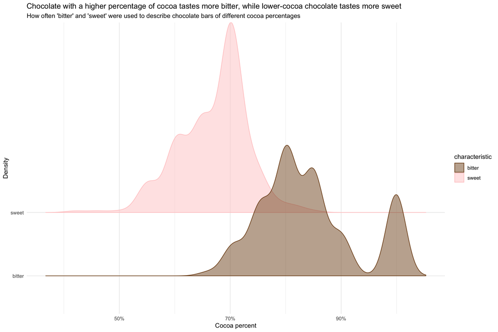

```r
# Ridgeline density plot
ggplot(chocolate2, aes(x = cocoa_percent, y = characteristic)) +
  geom_density_ridges2(aes(fill = characteristic, color = characteristic), alpha = 0.5, scale = 3) +
  scale_fill_manual(values = c("#825325","#ffcccc")) +
  scale_color_manual(values = c("#825325","#ffcccc")) +
  theme_minimal() +
  scale_x_continuous(labels = scales::label_percent(scale = 1, accuracy = 1)) +
  labs(title = "Chocolate with a higher percentage of cocoa tastes more bitter, while lower-cocoa chocolate tastes more sweet",
       subtitle = "How often 'bitter' and 'sweet' were used to describe chocolate bars of different cocoa percentages",
       x = "Cocoa percent",
       y = "Density")
```

```r
# I created the data frame "bittersweet," where each row is a cocoa_percent and there are columns for the number of times "sweet" or "bitter" have been used to describe that cocoa_percent
bittersweet <- chocolate2 %>%
  group_by(cocoa_percent) %>%
  summarize_at(c("bitter", "sweet"), sum)

# I created the data frame "bitterchocolate" containing just the chocolate bars described as bitter.
bitterchocolate <- chocolate2 %>%
  filter(bitter == 1)

# I created the data frame "sweetchocolate" containing just the chocolate bars described as sweet.
sweetchocolate <- chocolate2 %>%
  filter(sweet == 1)

# I used the "bittersweet" data frame and two separate scatterplots to graph the number of times each cocoa_percent has been described as "bitter" or "sweet."
ggplot(bittersweet) +
  geom_point(aes(x = cocoa_percent, y = bitter),
             color = "#825325",
             alpha = 0.5,
             size = 2,
             shape = 16) +
  geom_point(aes(x = cocoa_percent, y = sweet),
             color = "#ffcccc",
             alpha = 0.5,
             size = 2,
             shape = 17) +
  theme_minimal()

# This is the same as the previous scatterplot, but using two separate column graphs.
ggplot(bittersweet) +
  geom_col(aes(x = cocoa_percent, y = bitter),
           fill = "#825325",
           alpha = 0.5,
           width = 2) +
  geom_col(aes(x = cocoa_percent, y = sweet),
           fill = "#ffcccc",
           alpha = 0.5,
           width = 2) +
  theme_minimal()

# This is two histograms overlaid, each using different data frames (bitterchocolate and sweetchocolate).
ggplot() +
  geom_histogram(data = bitterchocolate,
                 mapping = aes(x = cocoa_percent),
                 fill = "#825325",
                 alpha = 0.5) +
  geom_histogram(data = sweetchocolate,
                 mapping = aes(x = cocoa_percent),
                 fill = "#ffcccc",
                 alpha = 0.5) +
  theme_minimal()

# Same as the two histograms, but using density plots, and adding some annotation to a part of the graph I found interesting.
ggplot() +
  geom_density(data = bitterchocolate,
               mapping = aes(x = cocoa_percent),
               fill = "#825325",
               color = "#825325",
                 alpha = 0.5) +
  geom_density(data = sweetchocolate,
               mapping = aes(x = cocoa_percent),
               fill = "#ffcccc",
               color = "#ffcccc",
               alpha = 0.5) +
  scale_x_continuous(labels = scales::label_percent(scale = 1, accuracy = 1)) +
  scale_y_continuous(breaks = seq(0, 0.1, by = 0.05)) +
  theme_minimal() +
  geom_curve(aes(x = 85, xend = 74.2, y = 0.07, yend = 0.03),
             size = 0.4,
             color = "#bf656f",
             arrow = arrow(type = "closed", length = unit(2, "mm"))) +
  annotate("text", x = 88, y = 0.07,
           label = paste('74% cocoa is a', "\n", 'nice balance of', "\n", 'bitter and sweet'),
           size = 3.5, color = "#bf656f") +
  labs(title = "Mmm chocolate is yummy",
       x = "Cocoa percent",
       y = "Density")
```

[output not shown]

## Plot 2

I used what I learned from Nicola Rennie’s Tidy Tuesday submission (linked below) about using geom_treemap to visualize descriptor frequency by chocolate rating.

Rating key from [Flavors of Cacao](http://flavorsofcacao.com/review_guide.html):

- 4.0 - 5.0 = Outstanding
- 3.5 - 3.9 = Highly Recommended
- 3.0 - 3.49 = Recommended
- 2.0 - 2.9 = Disappointing
- 1.0 - 1.9 = Unpleasant

Aside: It was too late when I realized that I might be able to create the same graphs using one faceted ggplot rather than four separate ggplots!

```r
characteristics <- chocolate %>%
  mutate(most_memorable_characteristics = strsplit(as.character(most_memorable_characteristics), ", ")) %>%
  unnest(most_memorable_characteristics) %>%
  mutate(rating_bin = case_when(
    (rating >= 4.0 & rating <= 5) ~ 'Outstanding',
    (rating >= 3.5 & rating <= 3.9) ~ 'Highly Recommend',
    (rating >= 3.0 & rating <= 3.49) ~ 'Recommend',
    (rating >= 2.0 & rating <= 2.9) ~ 'Disappointing',
    (rating <= 1.9) ~ 'Unpleasant'))

outstanding <- characteristics %>%
  filter(rating_bin == 'Outstanding') %>%
  group_by(most_memorable_characteristics) %>%
  summarize(count = n()) %>%
  arrange(desc(count))

highly_recommend <- characteristics %>%
  filter(rating_bin == 'Highly Recommend') %>%
  group_by(most_memorable_characteristics) %>%
  summarize(count = n()) %>%
  arrange(desc(count))

recommend <- characteristics %>%
  filter(rating_bin == 'Recommend') %>%
  group_by(most_memorable_characteristics) %>%
  summarize(count = n()) %>%
  arrange(desc(count))

disappointing <- characteristics %>%
  filter(rating_bin == 'Disappointing') %>%
  group_by(most_memorable_characteristics) %>%
  summarize(count = n()) %>%
  arrange(desc(count))

unpleasant <- characteristics %>%
  filter(rating_bin == 'Unpleasant') %>%
  group_by(most_memorable_characteristics) %>%
  summarize(count = n()) %>%
  arrange(desc(count))
```

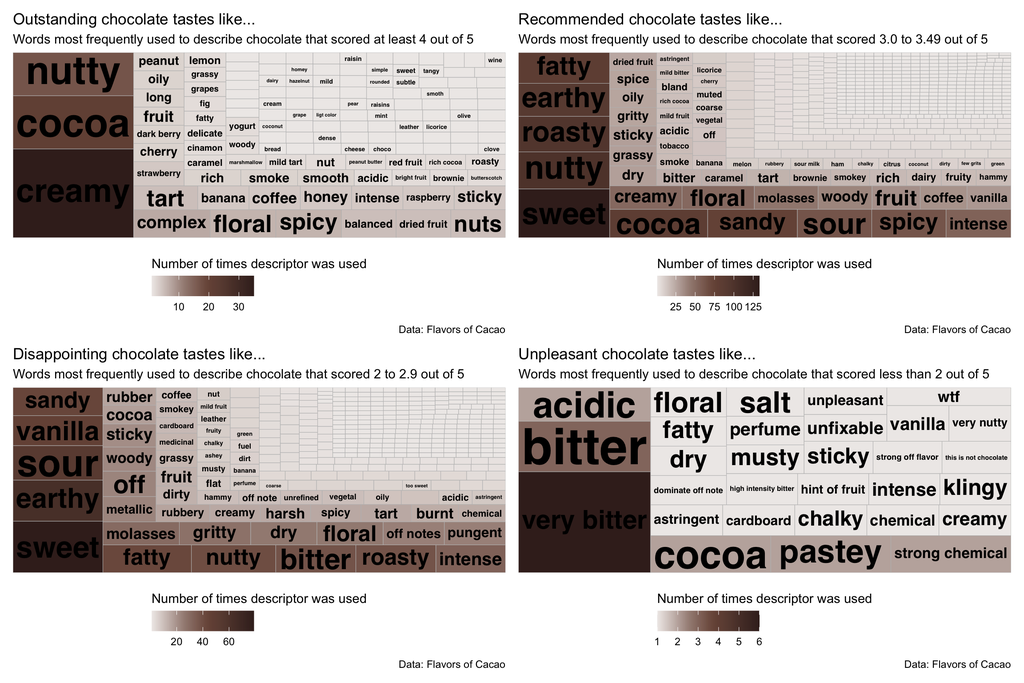

```r
outstanding_plot <-
  ggplot(outstanding, aes(area = count, fill= count, label = most_memorable_characteristics)) +
  geom_treemap() +
  geom_treemap_text(fontface = "bold",
                    family = "sans",
                    place = "center",
                    grow = TRUE) +
  scale_fill_material(palette = "brown",
                      name = "Number of times descriptor was used",
                      guide = guide_colorbar(title.position = "top")) +
  labs(title = "Outstanding chocolate tastes like...",
       subtitle = "Words most frequently used to describe chocolate that scored at least 4 out of 5",
       caption = "Data: Flavors of Cacao") +
  theme(legend.position = "bottom")

highly_recommend_plot <-
  ggplot(highly_recommend, aes(area = count, fill= count, label = most_memorable_characteristics)) +
  geom_treemap() +
  geom_treemap_text(fontface = "bold",
                    family="sans",
                    place = "center",
                    grow = TRUE) +
  scale_fill_material(palette = "brown",
                      name = "Number of times descriptor was used",
                      guide = guide_colorbar(title.position = "top")) +
  labs(title = "Highly recommended chocolate tastes like...",
       subtitle = "Words most frequently used to describe chocolate that scored 3.5 to 3.9 out of 5",
       caption = "Data: Flavors of Cacao") +
  theme(legend.position = "bottom")

recommend_plot <-
  ggplot(recommend, aes(area = count, fill= count, label = most_memorable_characteristics)) +
  geom_treemap() +
  geom_treemap_text(fontface = "bold",
                    family="sans",
                    place = "center",
                    grow = TRUE) +
  scale_fill_material(palette = "brown",
                      name = "Number of times descriptor was used",
                      guide = guide_colorbar(title.position = "top")) +
  labs(title = "Recommended chocolate tastes like...",
       subtitle = "Words most frequently used to describe chocolate that scored 3.0 to 3.49 out of 5",
       caption = "Data: Flavors of Cacao") +
  theme(legend.position = "bottom")

disappointing_plot <-
  ggplot(disappointing, aes(area = count, fill= count, label = most_memorable_characteristics)) +
  geom_treemap() +
  geom_treemap_text(fontface = "bold",
                    family="sans",
                    place = "center",
                    grow = TRUE) +
  scale_fill_material(palette = "brown",
                      name = "Number of times descriptor was used",
                      guide = guide_colorbar(title.position = "top")) +
  labs(title = "Disappointing chocolate tastes like...",
       subtitle = "Words most frequently used to describe chocolate that scored 2 to 2.9 out of 5",
       caption = "Data: Flavors of Cacao") +
  theme(legend.position = "bottom")

unpleasant_plot <-
  ggplot(unpleasant, aes(area = count, fill= count, label = most_memorable_characteristics)) +
  geom_treemap() +
  geom_treemap_text(fontface = "bold",
                    family="sans",
                    place = "center",
                    grow = TRUE) +
  scale_fill_material(palette = "brown",
                      name = "Number of times descriptor was used",
                      guide = guide_colorbar(title.position = "top")) +
  labs(title = "Unpleasant chocolate tastes like...",
       subtitle = "Words most frequently used to describe chocolate that scored less than 2 out of 5",
       caption = "Data: Flavors of Cacao") +
  theme(legend.position = "bottom")

# Assemble the plots with the patchwork package
(outstanding_plot | recommend_plot) / (disappointing_plot | unpleasant_plot)
```

# Review

## Find and run

| Name | Details |
| --- | --- |
| Author | Nicola Rennie |
| Tweet | [url](https://twitter.com/nrennie35/status/1483774741613789184) |
| Code | [url](https://github.com/nrennie/tidytuesday/blob/main/2022/2022-01-18/20220118.R) |

```r
# load libraries
# library(tidyverse) # already loaded
# library(treemapify) # already loaded
# library(showtext) # already loaded
# library(ggsci) # already loaded

# load data
# tuesdata <- tidytuesdayR::tt_load('2022-01-18') # already loaded
# chocolate <- tuesdata$chocolate # already loaded

# add fonts
font_add_google(name = "Bebas Neue", family = "bebas")
showtext_auto()

# prep data
plot_data <- chocolate %>%
  group_by(country_of_bean_origin) %>%
  summarise(n = n(),
            rating = mean(rating)) %>%
  arrange(desc(n))
plot_data
```

```
## # A tibble: 62 × 3
##    country_of_bean_origin     n rating
##    <chr>                  <int>  <dbl>
##  1 Venezuela                253   3.23
##  2 Peru                     244   3.20
##  3 Dominican Republic       226   3.22
##  4 Ecuador                  219   3.16
##  5 Madagascar               177   3.27
##  6 Blend                    156   3.04
##  7 Nicaragua                100   3.26
##  8 Bolivia                   80   3.18
##  9 Colombia                  79   3.20
## 10 Tanzania                  79   3.23
## # … with 52 more rows
```

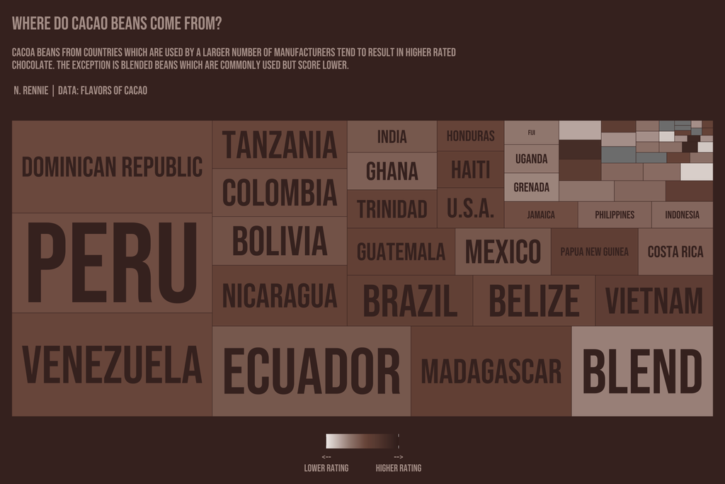

```r
# treemap plot
ggplot(plot_data, aes(area = n, fill = rating, label = country_of_bean_origin)) +
  geom_treemap(colour = "#452d28") +
  geom_treemap_text(fontface = "italic",
                    family="bebas",
                    colour = "#452d28",
                    place = "centre",
                    grow = TRUE,
                    padding.x = grid::unit(4, "mm"),
                    padding.y = grid::unit(4, "mm")) +
  scale_fill_material(palette="brown", name="",
                      limits=c(2.8, 3.6),
                      breaks=c(2.8, 3.6),
                      labels=c("<--\nLower rating", "-->\nHigher rating"),
                      guide = guide_colourbar(title.position = "top")) +
  labs(title = "Where do cacao beans come from?",
       subtitle = "\nCacoa beans from countries which are used by a larger number of manufacturers tend to result in higher rated\nchocolate. The exception is blended beans which are commonly used but score lower. \n\n N. Rennie | Data: Flavors of Cacao\n\n") +
  theme_void() +
  theme(plot.background = element_rect(fill = "#452d28", colour="#452d28"),
        panel.background = element_rect(fill = "#452d28", colour="#452d28"),
        legend.position = "bottom",
        plot.title = element_text(colour = '#b29e97', family="bebas", face = "bold", size=22),
        plot.subtitle = element_text(colour = '#b29e97', family="bebas", size=14),
        legend.text = element_text(colour = '#b29e97', family="bebas", size=12),
        legend.title = element_text(colour = '#b29e97', family="bebas", size=12),
        plot.margin = unit(c(0.5, 0.5, 0.5, 0.5), "cm"))
```

## Notes

### Data wrangling

I learned from Nicola Rennie’s code how to use the n() function inside the summarize() function to summarize counts across a group. Before, I had only used sum() and mean() inside of summarize(). This was very helpful in creating the frequency tables needed to power my treemaps

### Treemaps

Mimicking Rennie’s code was an extremely helpful way to learn geom_treemap for the first time. A few things in particular that she did very effectively:

- Rennie’s data viz works along two dimensions: the size of each rectangle corresponds to frequency while the color of each rectangle (shade of brown) corresponds to rating. Her use of two dimensions in the treemap helps surface the positive relationship between ratings and country-frequency. She summarizes this takeaway in a helpful subtitle. She also points out that “Blend” is an important exception to the trend. (In contrast, I used just one dimension in my treemap. I mapped both size and color in my treemaps to the frequency of chocolate descriptors.)
- Rennie’s treemap works so well because there is a healthy spread in the distribution of chocolate bars across countries. On the other hand, in my treemaps, only a handful of descriptors were used over and over, with most of the rest being “singleton sets.” As a result, my treemaps were not visually very striking. A different geom might have been a better way to visualize descriptors (picking, say, just the top five of each rating category).
- I love that Rennie’s brown rectangular treemap visually resembles a bar of chocolate.